# Case Study 2

Jeff Chandler

December 1, 2016

# **INTRODUCTION**

### This project entails four primary sections with multiple tasks under each section. This project was primarily done in R, however in the first section there will be 2 pieces of code that are for SAS and Python.

## This section of code will perform the following items:

- Create the X matrix and print from result from SAS

  SAS code

  ```
  proc iml;
  reset print;
  X = {4 5 1 2,
          1 0 3 5,
          2 1 8 2};
  print X;
  ```

- Create the X matrix and print from result from Python

  ```
  Python Code
    import numpy as np
    X = np.matrix([[4,5,1,2], [1,0,3,5],[2,1,8,2]])
    X
    matrix([[4, 5, 1, 2],
            [1, 0, 3, 5],
            [2, 1, 8, 2]])
  ```

- Create the X matrix and print from result from R

```r
r = c(4,5,1,2,1,0,3,5,2,1,8,2)
X = matrix(r, nrow=3, ncol = 4, byrow = TRUE)
print(X)
```

```
##      [,1] [,2] [,3] [,4]
## [1,]    4    5    1    2
## [2,]    1    0    3    5
## [3,]    2    1    8    2
```

## This section of code will perform the following items:

- Download the data for S&P stock AGIO
- Calculate log returns.
- Calculate volatility measure.
- Calculate volatility over entire length of series for the different decay factors.
- Plot the results, overlaying the volatility curves on the data, just as was done in the S&P example.

```r
##Set Working directory
setwd('C:\\RProjects\\CaseStudy2\\Analysis')

##Install tseries package
source('Packageinstall.R')
```

```
## [1] "Package is already installed"
```

```r
##get the data
histquot = get.hist.quote('agio', quote = 'Close')
```

```
## time series starts 2013-07-24
```

```r
##Get return
snpreturn = log(lag(histquot)) - log(histquot)

##volatility
snpvol = sd(snpreturn) * sqrt(250) * 100
##Function
vol = function(d, logrets){
  var=0
  lam=0
  varlist = c()
  for (r  in logrets)
  {
    lam = lam*(1 -1/d) + 1
    var = (1-1/lam)*var + (1/lam)*r^2
    varlist = c(varlist, var)

  }
  sqrt(varlist)
}
volest = vol(10,snpreturn)
volest1 = vol(30, snpreturn)
volest2 = vol(100, snpreturn)
head(volest)
```

```
## [1] 0.11866257 0.08392480 0.06670686 0.05683052 0.04941728 0.04382814
```

```r
head(volest1)
```

```
## [1] 0.11866257 0.08533422 0.06911573 0.05990054 0.05312161 0.04807147
```

```r
head(volest2)
```

```
## [1] 0.11866257 0.08580004 0.06991457 0.06092605 0.05436410 0.04950193
```

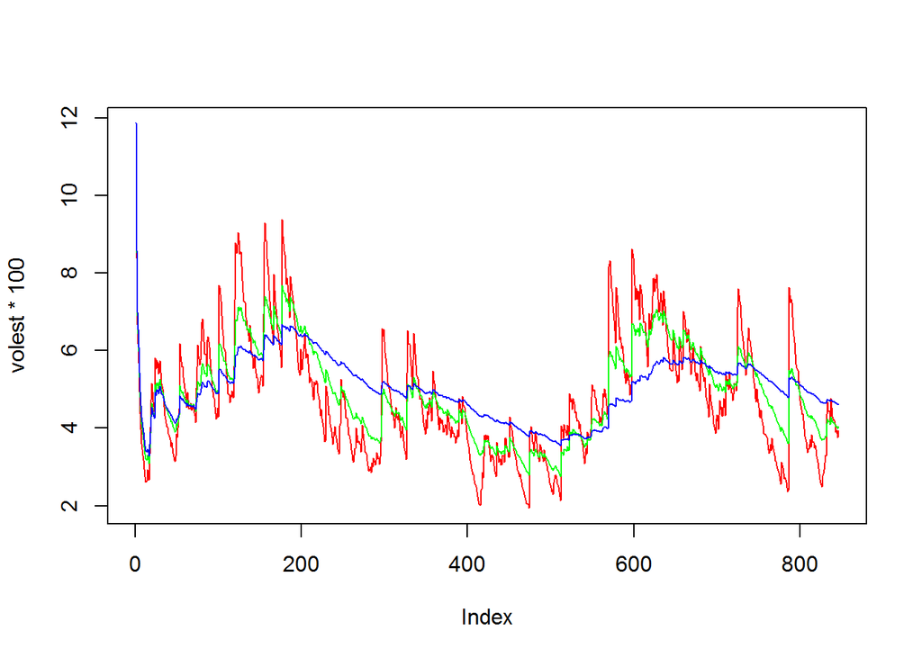

```r
plot(volest*100, type = 'l', col='red')
lines(volest1*100, type = 'l',col='green')
lines(volest2*100, type = 'l', col='blue')
```

## This section of code we will use the built-in dataset from R called Orange and perform the following:

- Calculate the mean and the median of the trunk circumferences for different size of the trees. (Tree)
- Make a scatter plot of the trunk circumferences against the age of the tree. Use different plotting symbols for different size of trees.
- Display the trunk circumferences on a comparative boxplot against tree. Be sure you order the boxplots in the increasing order of maximum diameter.

```r
print(aggregate(Orange[3], list(Orange$Tree), mean))
```

```
##   Group.1 circumference
## 1       3      94.00000
## 2       1      99.57143
## 3       5     111.14286
## 4       2     135.28571
## 5       4     139.28571
```

```r
print(aggregate(Orange[3], list(Orange$Tree), median))
```

```
##   Group.1 circumference
## 1       3           108
## 2       1           115
## 3       5           125
## 4       2           156
## 5       4           167
```

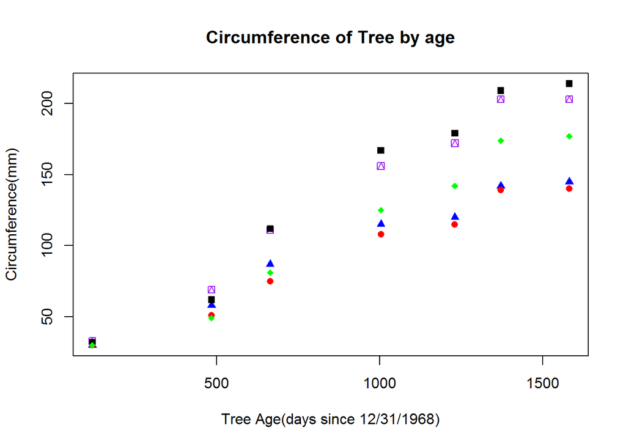

```r
plot(Orange$age, Orange$circumference, pch=c(16,17,18,14,15)[as.numeric(Orange$Tree)], main='Circumference of Tree by age'
      , col=c('red','blue','green', 'purple', 'black')[as.numeric(Orange$Tree)],xlab = 'Tree Age(days since 12/31/1968)', ylab = 'Circumference(mm)')
```

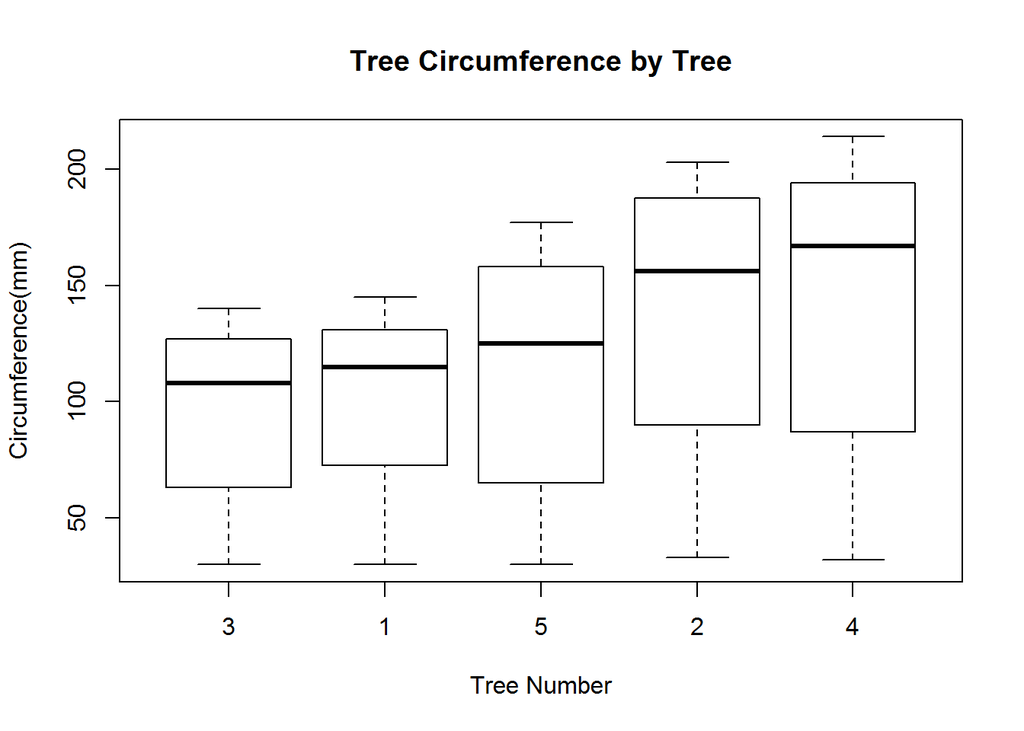

```r
##boxplots
boxplot(Orange$circumference~Orange$Tree, main='Tree Circumference by Tree', xlab='Tree Number', ylab='Circumference(mm)')
```

##In this section we have 3 subsections of tasks that will be performed * Find the difference between the maximum and the minimum monthly average temperatures for each country and report/visualize top 20 countries with the maximum differences for the period since 1900.

[figure not shown]

```r
CityTempFile = 'C:\\RProjects\\CaseStudy2\\Analysis\\Data\\citytemp.csv'
WorldTempFile = 'C:\\RProjects\\CaseStudy2\\Analysis\\Data\\TEMP.csv'
##read the file
##read the file
WorldTemp = read.csv(WorldTempFile, sep = ',', header = TRUE, stringsAsFactors = FALSE)

library(stringr)
library(plyr)


#get rid of any dates less than year 1900
WorldTemp$Year =  ifelse(grepl('-',WorldTemp$Date), unlist(str_split_fixed(WorldTemp$Date, '-', 3), recursive = FALSE)[,1],'2')
WorldTemp$Year = as.numeric(WorldTemp$Year)
WorldTemp = subset(WorldTemp, (WorldTemp$Year >1899) | (WorldTemp$Year == 2))
##check the next format of dates
WorldTemp$Year =  ifelse(grepl('/',WorldTemp$Date), unlist(str_split_fixed(WorldTemp$Date, '/', 3), recursive = FALSE)[,3],'2')
WorldTemp$Year = as.numeric(WorldTemp$Year)
WorldTemp = subset(WorldTemp, (WorldTemp$Year >1899) | (WorldTemp$Year == 2))
##break out month
WorldTemp$Month =  ifelse(grepl('/',WorldTemp$Date), unlist(str_split_fixed(WorldTemp$Date, '/', 3), recursive = FALSE)[,1],'2')
##convert temp
WorldTemp$Monthly.AverageTemp = as.numeric(WorldTemp$Monthly.AverageTemp)
##remove NA
WorldTemp = subset(WorldTemp, WorldTemp$Monthly.AverageTemp !='NA')

#get mean by month
#v = tapply(WorldTemp$Monthly.AverageTemp, by=c('WorldTemp$Month', 'WorldTemp$Country'), mean)
v = aggregate(WorldTemp$Monthly.AverageTemp, by = list(WorldTemp$Month, WorldTemp$Country), FUN=mean, na.rm=TRUE)
xmin = round(tapply(v$x, v$Group.2, min), digits = 2)
xmax = round(tapply(v$x, v$Group.2, max), digits = 2)

##merge the data
cminmax = data.frame(xmin,xmax)
##convert row names
cminmax = cbind(country = rownames(cminmax), cminmax)
##calculate the difference
cminmax$diff = cminmax$xmax - cminmax$xmin
##order by diff
cminmax = cminmax[order(cminmax$diff, decreasing = TRUE),]
##get top 20
top20 = cminmax[1:20,]

##plot results
#plot(top20$diff, col='blue', x=top20$country)

par(las=2)
par(mar=c(8,4,2,2))
barplot(top20$diff, main = 'Largest Tempature Difference', xlab = 'Country', ylab = 'Degree (F)')
```

- This subsetion performs the following 3 tasks:
  1. Create a new column to display the monthly average land temperatures in Fahrenheit (°F).
  2. Calculate average land temperature by year and plot it. The original file has the average land temperature by month.
  3. Calculate the one year difference of average land temperature by year and provide the maximum difference (value) with corresponding two years.

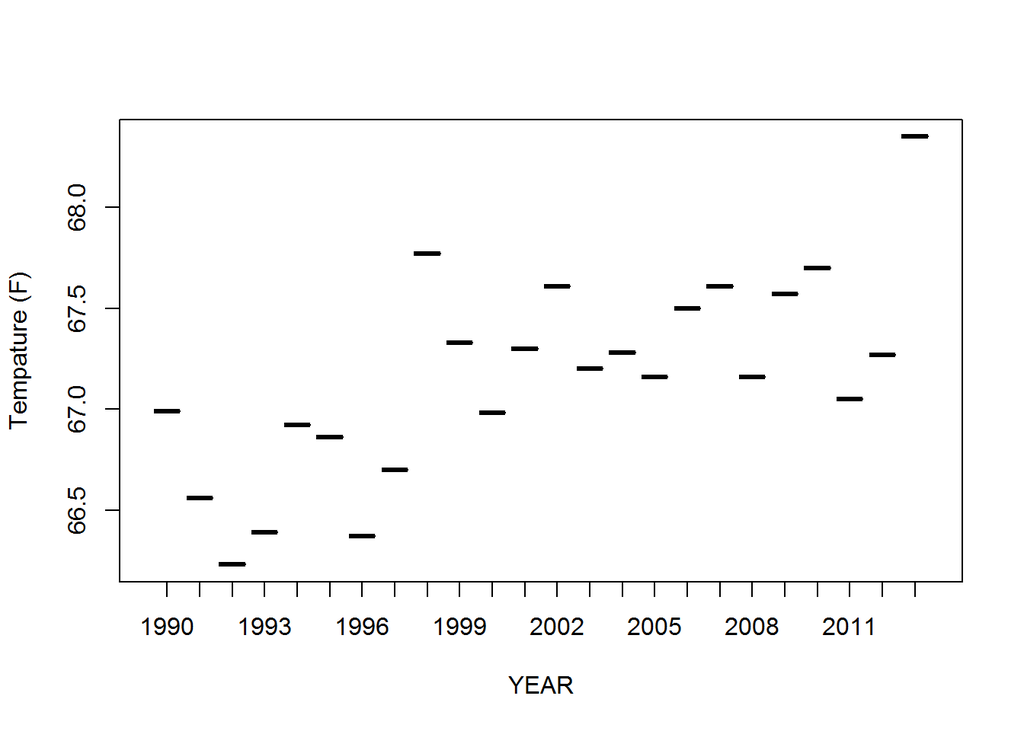

```r
##pull in City data
CityTemp = read.csv(CityTempFile, sep = ',', header = TRUE, stringsAsFactors = FALSE)


#get rid of any dates less than year 1900
CityTemp$Year =  ifelse(grepl('-',CityTemp$Date), unlist(str_split_fixed(CityTemp$Date, '-', 3), recursive = FALSE)[,1],'2')

##set year to numberic
CityTemp$Year = as.numeric(CityTemp$Year)

##subset the data
CityTemp = subset(CityTemp, (CityTemp$Year >1989) | (CityTemp$Year == 2))

##check the next format of dates
CityTemp$Year =  ifelse(grepl('/',CityTemp$Date), unlist(str_split_fixed(CityTemp$Date, '/', 3), recursive = FALSE)[,3],'2')
##change to number
CityTemp$Year = as.numeric(CityTemp$Year)
##subset based on year
CityTemp = subset(CityTemp, (CityTemp$Year >1989) | (CityTemp$Year == 2))
##break out month
CityTemp$Month =  ifelse(grepl('/',CityTemp$Date), unlist(str_split_fixed(CityTemp$Date, '/', 3), recursive = FALSE)[,1],'2')
##convert temp
CityTemp$Monthly.AverageTemp = as.numeric(CityTemp$Monthly.AverageTemp)
##remove NA
CityTemp = subset(CityTemp, CityTemp$Monthly.AverageTemp !='NA')

CityTemp$TempInFah = round(CityTemp$Monthly.AverageTemp *(9/5) + 32, digits = 2)

##get the average temp by year
v = round(tapply(CityTemp$TempInFah, CityTemp$Year, mean), digits = 2)
v = data.frame(v)

##convert row lable to column
v = cbind(Year = rownames(v), v)
##plot it

plot(v, xlab = "YEAR", ylab = 'Tempature (F)', col='red')
```

```r
#remove row names
colnames(v) = c('year', 'temp')
#drop the levels


for (i in 1:nrow(v$temp)) {
  if(i > 1){
    print(v$temp[i] - v$temp[i-1], row.names = FALSE)
  }
}
```

```
##  1991
## -0.43
##  1992
## -0.33
## 1993
## 0.16
## 1994
## 0.53
##  1995
## -0.06
##  1996
## -0.49
## 1997
## 0.33
## 1998
## 1.07
##  1999
## -0.44
##  2000
## -0.35
## 2001
## 0.32
## 2002
## 0.31
##  2003
## -0.41
## 2004
## 0.08
##  2005
## -0.12
## 2006
## 0.34
## 2007
## 0.11
##  2008
## -0.45
## 2009
## 0.41
## 2010
## 0.13
##  2011
## -0.65
## 2012
## 0.22
## 2013
## 1.08
```

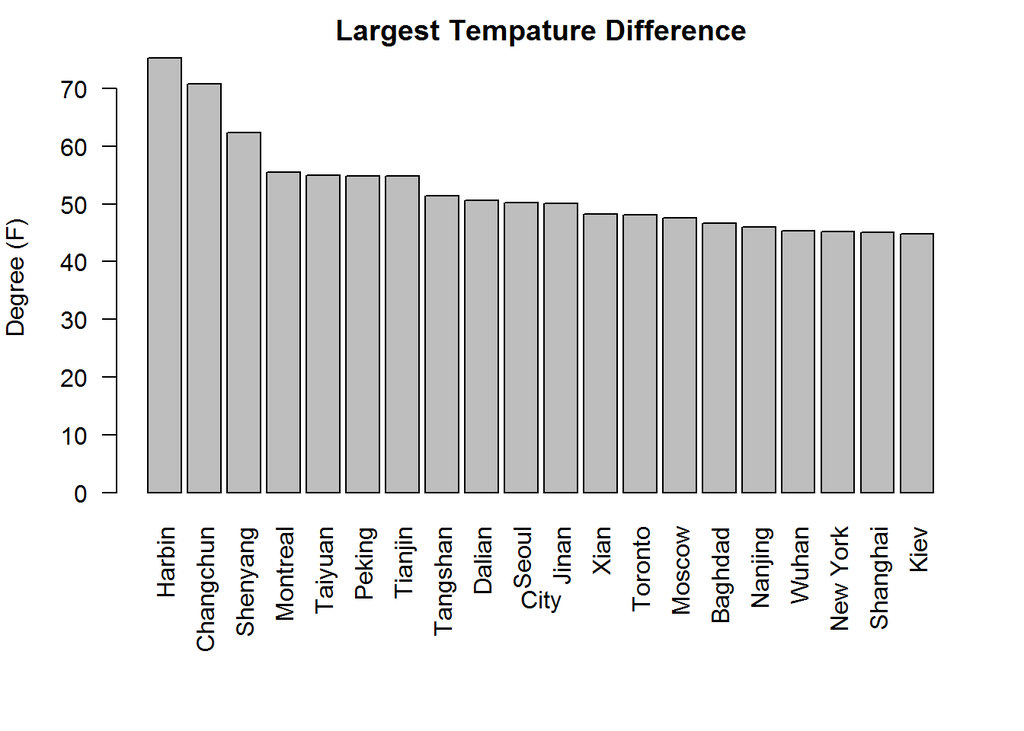

```r
##this section showscity temp
CityTemp$Month = as.numeric(CityTemp$Month)


v2 = aggregate(CityTemp$TempInFah, by = list(CityTemp$Month, CityTemp$City), FUN=mean, na.rm=TRUE)
xmin = round(tapply(v2$x, v2$Group.2, min), digits = 2)
xmax = round(tapply(v2$x, v2$Group.2, max), digits = 2)


##merge the data
cminmax = data.frame(xmin,xmax)
##convert row names
cminmax = cbind(country = rownames(cminmax), cminmax)
##calculate the difference
cminmax$diff = cminmax$xmax - cminmax$xmin
##order by diff
cminmax = cminmax[order(cminmax$diff, decreasing = TRUE),]
##get top 20
top20 = cminmax[1:20,]

##plot results
par(las=2)
par(mar=c(8,4,2,2))
barplot(top20$diff, main = 'Largest Tempature Difference', xlab = 'City', ylab = 'Degree (F)')
```

# **CONCLUSION**

### In conclusion, it is clear from the Country and City graphs that those Countries and Cities that are farther North have a much larger differential in tempature that those closer to the equator.